# LLM Fine Tuning-New York Times Comments(2017)

Author

Francis Lauder

Published

January 24, 2026

# Introduction

Sentiment analysis involves assigning predefined categories to text, We use use our understanding of the emotional intent of words to infer whether a section of text is negative, neutral, or positive. For our project we will predict sentiment using a pre-trained large language model (llm) from Hugging Face which we will fine-tune on our specific data. A pre-trained model is a LLM trained on a broad dataset to learn general patterns. Through this process is where model parameters and weights are learned. This can be a time-consuming process thus by using a pre-trained the heavy lifting has been borne by the authors of the model . This makes it easier to update the weights of the model on specific data to adapt it for specialized tasks. For the fine-tuning we will use a New York Times 2017 dataset of comments already including sentiment labels. This was accomplished in a previous project using the AFINN method. The AFINN method is a rule-based approach which has a dictionary of words and each word has an intensity score ranging from -5 to 5. The overall sentiment score of a text is calculated by summing the intensity scores. Fine-tuning of the pre-trained model is different as it is a machine learning process. We train the model on a training subset of our specific data and evaluate it on a testing subset of our specific data. These models differ from rule-based methods as they do not look at words in isolation; they look at the whole sentence, understand word order, context, and sarcasm. Once the fine-tuning of the pre-trained model is finished, we will use it to predict sentiment of unlabeled comments from the New York Times 2018 dataset.

We will be using the pre-trained cardiffnlp/twitter-roberta-base-sentiment-latest model. The license can be viewed at the link below.

[cardiffnlp license](https://creativecommons.org/licenses/by/4.0/)

# Data Inspection

## Libraries

```python
import pandas as pd
import matplotlib.pyplot as plt
import seaborn as sns
import numpy as np
import pickle
import sklearn
from sklearn.model_selection import train_test_split
from pprint import pprint
```

```python
from transformers import pipeline, AutoModel, AutoTokenizer, AutoModelForSequenceClassification, AutoConfig,Trainer, TrainingArguments
```

```python
import torch
import torch.nn.functional as F
import torchtext
from datasets import Dataset, DatasetDict
```

We will first check and verify that the gpu is available.

```python
torch.cuda.is_available()
```

```
True
```

The ‘True’ output means the gpu is available.

# Data Review

## Data Review

```python
print("nyt_sentiment_17 dataset shape: \n",nyt_sentiments17.shape)
```

```
nyt_sentiment_17 dataset shape:
 (969655, 8)
```

The dataset has just under 970,000 rows and 8 columns.

```python
print("nyt_sentiment17 dataset structure: \n\n",nyt_sentiments17.info())
```

```
<class 'pandas.core.frame.DataFrame'>
RangeIndex: 969655 entries, 0 to 969654
Data columns (total 8 columns):
 #   Column           Non-Null Count   Dtype
---  ------           --------------   -----
 0   commentBody      969655 non-null  object
 1   commentID        969655 non-null  int64
 2   newDesk          969655 non-null  object
 3   typeOfMaterial   969655 non-null  object
 4   clean_comments   969652 non-null  object
 5   sentiment_score  969655 non-null  int64
 6   sentiment        969655 non-null  object
 7   label            969655 non-null  int64
dtypes: int64(3), object(5)
memory usage: 59.2+ MB
nyt_sentiment17 dataset structure:

 None
```

We used the .info() method to display the column names. It is important to note that when configuring the pre-trained model, we will need the sentiment column, which is the label name, and the label column which is the numerical representation of the sentiment column. For the pre-trained model we have selected, if both columns are not present in the dataset, training the model will result in an error. In the pre-processing steps we will see why.

```python
print("Sentiment and label columns: \n\n",nyt_sentiments17.iloc[:,6:8].head(2))
```

```
Sentiment and label columns:

   sentiment  label
0  positive      2
1  negative      0
```

```python
print("Sentiment value counts: \n\n",nyt_sentiments17["sentiment"].value_counts())
```

```
Sentiment value counts:

 sentiment
negative    415486
positive    409187
neutral     144982
Name: count, dtype: int64
```

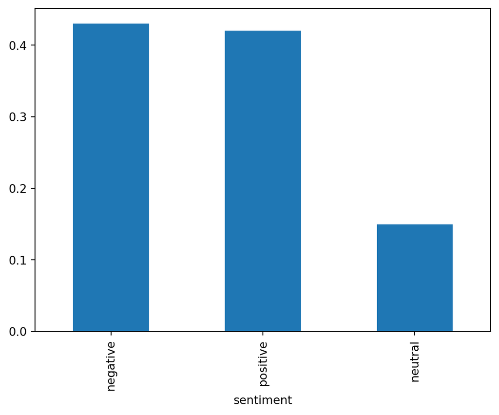

```python
nyt_sentiments17["sentiment"].value_counts(normalize=True).round(2).plot(kind='bar')
```

The percentage breakdown of sentiment is negative 43%, positive 42%, and neutral 15%. We will need to keep these percentages during the sampling of the data and splitting it into train, test, and validation sets.

# Pre-process

## Features

```python
print("nyt_sentiments17_2 dataset structure: \n\n",nyt_sentiments17_2.info())
```

```
<class 'pandas.core.frame.DataFrame'>
RangeIndex: 969655 entries, 0 to 969654
Data columns (total 8 columns):
 #   Column           Non-Null Count   Dtype
---  ------           --------------   -----
 0   commentBody      969655 non-null  object
 1   commentID        969655 non-null  int64
 2   newDesk          969655 non-null  object
 3   typeOfMaterial   969655 non-null  object
 4   clean_comments   969652 non-null  object
 5   sentiment_score  969655 non-null  int64
 6   sentiment        969655 non-null  object
 7   label            969655 non-null  int64
dtypes: int64(3), object(5)
memory usage: 59.2+ MB
nyt_sentiments17_2 dataset structure:

 None
```

```python
nyt_comments_dict = {"commentBody":"text", "sentiment":"label_name"}
```

```python
nyt_sentiments17_2 = nyt_sentiments17_2.rename(columns={"clean_comments":"text", "sentiment":"label_name"})
```

Columns not required for fine tuning and prediction will be dropped

```python
nyt_sentiments17_2=nyt_sentiments17_2.drop(columns=['commentBody','commentID', 'typeOfMaterial', 'newDesk','sentiment_score'], axis=1)
```

```python
print("nyt_sentiments17_2 structure with renamed columns: \n\n",nyt_sentiments17_2.info())
```

```
<class 'pandas.core.frame.DataFrame'>
RangeIndex: 969655 entries, 0 to 969654
Data columns (total 3 columns):
 #   Column      Non-Null Count   Dtype
---  ------      --------------   -----
 0   text        969652 non-null  object
 1   label_name  969655 non-null  object
 2   label       969655 non-null  int64
dtypes: int64(1), object(2)
memory usage: 22.2+ MB
nyt_sentiments17_2 structure with renamed columns:

 None
```

```python
nyt_sentiments17_2[['label','label_name']].value_counts(normalize=True).round(2)
```

```
label  label_name
0      negative      0.43
2      positive      0.42
1      neutral       0.15
Name: proportion, dtype: float64
```

Our dataset’s sentiment labels now match the pre-trained model.

## Train Test Validation split

Our dataset will be split into training, validation, and testing sets. Before we initiate the split we will sample and shuffle our data.

```python
nyt_shuffled_large = nyt_sentiments17_2.sample(frac=0.25, random_state=42).reset_index(drop=True)
```

```python
nyt_shuffled_large = nyt_shuffled_large.dropna()
```

```python
print("Sampled dataset shape: \n",nyt_shuffled_large.shape)
```

```
Sampled dataset shape:
 (242412, 3)
```

```python
print("Sampled dataset sentiment labels by percentage: \n\n",nyt_shuffled_large[['label', 'label_name']].value_counts(normalize=True).round(2))
```

```
Sampled dataset sentiment labels by percentage:

 label  label_name
0      negative      0.43
2      positive      0.42
1      neutral       0.15
Name: proportion, dtype: float64
```

70% of the comments will be used for the training set, 10% for the validation set, and the remaining %20 for the testing set.

```python
train_shape=train.shape
test_shape= test.shape
validation_shape=validation.shape
```

```python
print(f"Train Set Shape: {train_shape}, Test Set Shape: {test_shape} Validation Set Shape: {validation_shape}")
```

```
Train Set Shape: (169688, 3), Test Set Shape: (48482, 3) Validation Set Shape: (24242, 3)
```

```python
print("Train set sentiment percentage values: \n",train['label_name'].value_counts(normalize=True).round(2))
```

```
Train set sentiment percentage values:
 label_name
negative    0.43
positive    0.42
neutral     0.15
Name: proportion, dtype: float64
```

```python
print("Test set sentiment percentage values: \n",test['label_name'].value_counts(normalize=True).round(2))
```

```
Test set sentiment percentage values:
 label_name
negative    0.43
positive    0.42
neutral     0.15
Name: proportion, dtype: float64
```

```python
print("Validation set sentiment percentage values: \n",validation['label_name'].value_counts(normalize=True).round(2))
```

```
Validation set sentiment percentage values:
 label_name
negative    0.43
positive    0.42
neutral     0.15
Name: proportion, dtype: float64
```

## Dataset

The format of our data must be compatible with the transformers from Hugging Face, This can be done by using the DatasetDict function which creates a dictionary-like container. We will use it to hold our train, test, and validation splits.

```python
dataset = DatasetDict(
    {'train':Dataset.from_pandas(train, preserve_index=False),
    'test':Dataset.from_pandas(test, preserve_index=False),
    'validation':Dataset.from_pandas(validation, preserve_index=False)}
)
```

```python
print("dataset is of type: ",type(dataset))
```

```
dataset is of type:  <class 'datasets.dataset_dict.DatasetDict'>
```

```python
print("dataset structure: \n\n",dataset)
```

```
dataset structure:

 DatasetDict({
    train: Dataset({
        features: ['text', 'label_name', 'label'],
        num_rows: 169688
    })
    test: Dataset({
        features: ['text', 'label_name', 'label'],
        num_rows: 48482
    })
    validation: Dataset({
        features: ['text', 'label_name', 'label'],
        num_rows: 24242
    })
})
```

The dataset has a dictionary structure in which the train, test,validation splits are the names of the keys and the values are features: text, label_name, and label.

```python
print("Train/Dataset first row: \n",dataset['train'][0])
```

```
Train/Dataset first row:
 {'text': 'Trump had no idea what he was talking about platitudes and what the Israeli wanted to hear were all that came out of his mouth This is the kind of loose talk that can really throw a wrench into policy', 'label_name': 'negative', 'label': 0}
```

Filtering on the train key and first values we see the text, label_name, and label.